# Projet Statistique : Analyse des données médicales

### 3.2.1 3.2.1 Histogrammes et boxplots

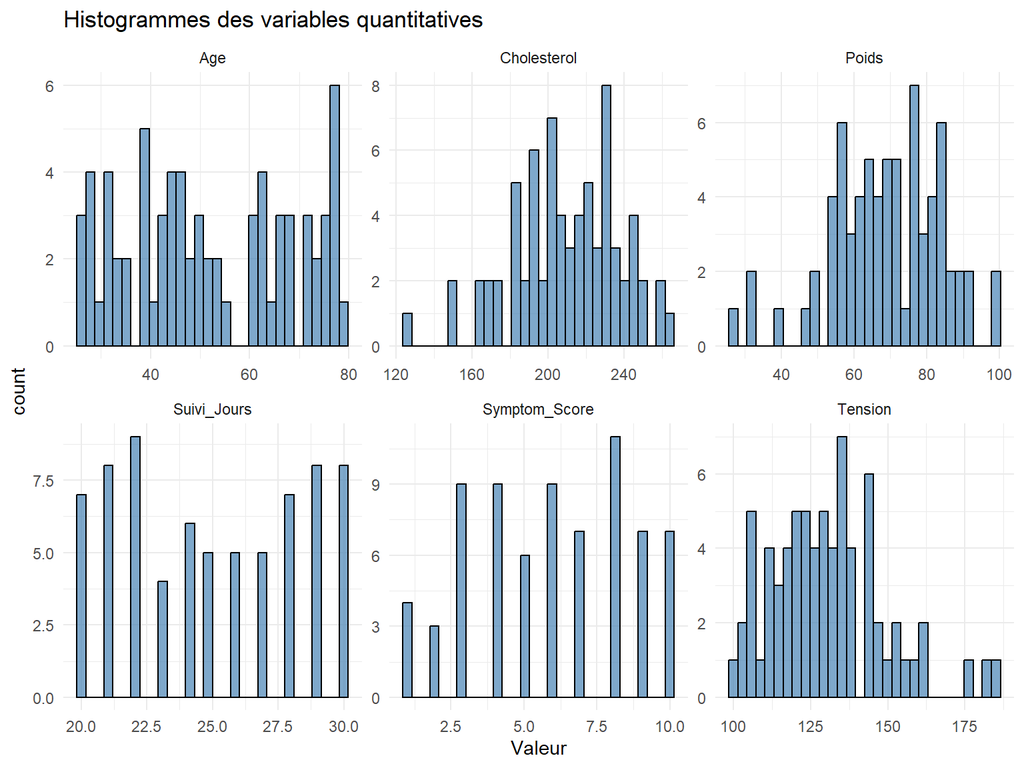

```r
numeric_vars_long <- data_clean %>%
  select(Age, Poids, Tension, Cholesterol, Suivi_Jours, Symptom_Score) %>%
  pivot_longer(cols = everything(), names_to = "Variable", values_to = "Valeur")

ggplot(numeric_vars_long, aes(x = Valeur)) +
  geom_histogram(bins = 30, color = "black", fill = "steelblue", alpha = 0.7) +
  facet_wrap(~ Variable, scales = "free") +
  theme_minimal() +
  labs(title = "Histogrammes des variables quantitatives")
```

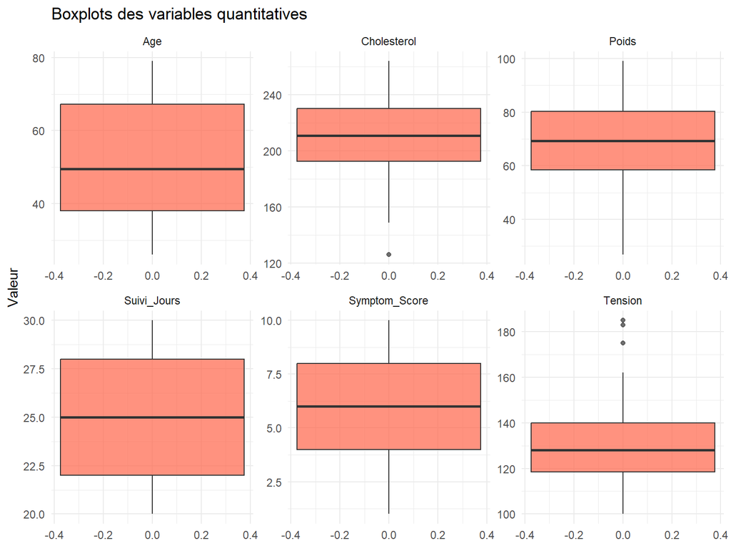

```r
ggplot(numeric_vars_long, aes(y = Valeur)) +
  geom_boxplot(fill = "tomato", alpha = 0.7) +
  facet_wrap(~ Variable, scales = "free") +
  theme_minimal() +
  labs(title = "Boxplots des variables quantitatives")
```

Interprétation (à adapter) :  
- Les histogrammes permettent de voir si les distributions sont **symétriques** ou **asymétriques**.  
- Les boxplots mettent en évidence d’éventuels **outliers** (valeurs extrêmes).

### 3.2.2 3.2.2 Test de normalité (Shapiro-Wilk)

```r
apply(numeric_vars, 2, function(x) {
  shapiro.test(x)$p.value
})
```

```
##           Age         Poids       Tension   Cholesterol   Suivi_Jours
##  0.0010081477  0.2311548319  0.0107719406  0.4310811374  0.0001052205
## Symptom_Score
##  0.0044595347
```

Interprétation :  
- Si le **p-value < 0,05**, on rejette l’hypothèse de normalité pour la variable.  
- Si le **p-value ≥ 0,05**, la normalité est compatible avec les données.

## 3.3 3.3 Variables qualitatives

On s’intéresse ici à `Sexe` et `Groupe_Traitement`.

```r
table(data_clean$Sexe)
```

```
##
##  F  M
## 30 42
```

```r
prop.table(table(data_clean$Sexe))
```

```
##
##         F         M
## 0.4166667 0.5833333
```

```r
table(data_clean$Groupe_Traitement)
```

```
##
##  A  B
## 40 32
```

```r
prop.table(table(data_clean$Groupe_Traitement))
```

```
##
##         A         B
## 0.5555556 0.4444444
```

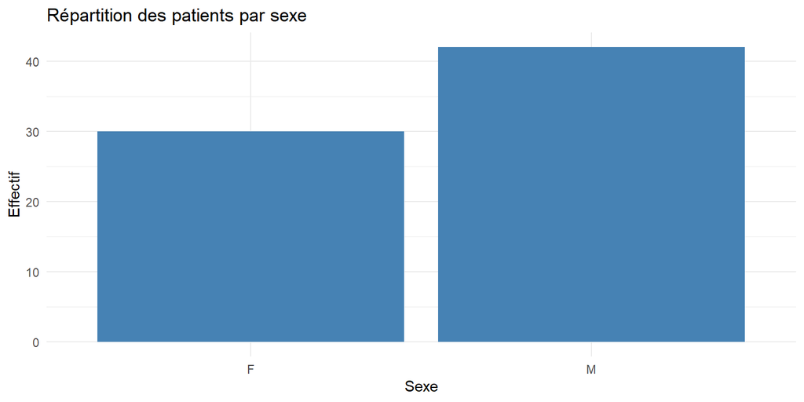

```r
ggplot(data_clean, aes(x = Sexe)) +
  geom_bar(fill = "steelblue") +
  theme_minimal() +
  labs(title = "Répartition des patients par sexe", x = "Sexe", y = "Effectif")
```

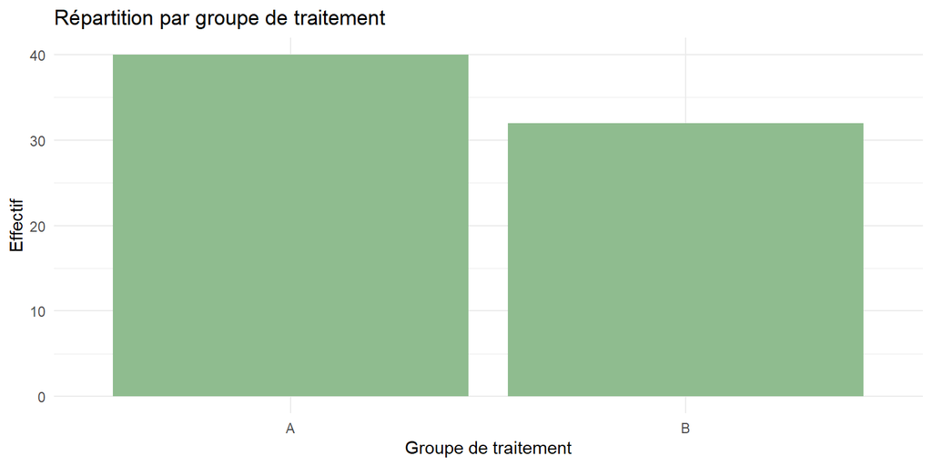

```r
ggplot(data_clean, aes(x = Groupe_Traitement)) +
  geom_bar(fill = "darkseagreen") +
  theme_minimal() +
  labs(title = "Répartition par groupe de traitement", x = "Groupe de traitement", y = "Effectif")
```

# 4 4. Analyse bivariée

## 4.1 4.1 Corrélation entre variables quantitatives

```r
cor_matrix <- cor(numeric_vars, use = "complete.obs")
cor_matrix
```

```
##                        Age       Poids      Tension Cholesterol Suivi_Jours
## Age            1.000000000  0.07581081 -0.007322607 -0.06885022 -0.06815034
## Poids          0.075810814  1.00000000 -0.110141073  0.06623760  0.05151972
## Tension       -0.007322607 -0.11014107  1.000000000  0.03471370 -0.03240724
## Cholesterol   -0.068850218  0.06623760  0.034713702  1.00000000  0.02892325
## Suivi_Jours   -0.068150342  0.05151972 -0.032407243  0.02892325  1.00000000
## Symptom_Score  0.168343356  0.09557221 -0.119349464 -0.03796789 -0.11738130
##               Symptom_Score
## Age              0.16834336
## Poids            0.09557221
## Tension         -0.11934946
## Cholesterol     -0.03796789
## Suivi_Jours     -0.11738130
## Symptom_Score    1.00000000
```

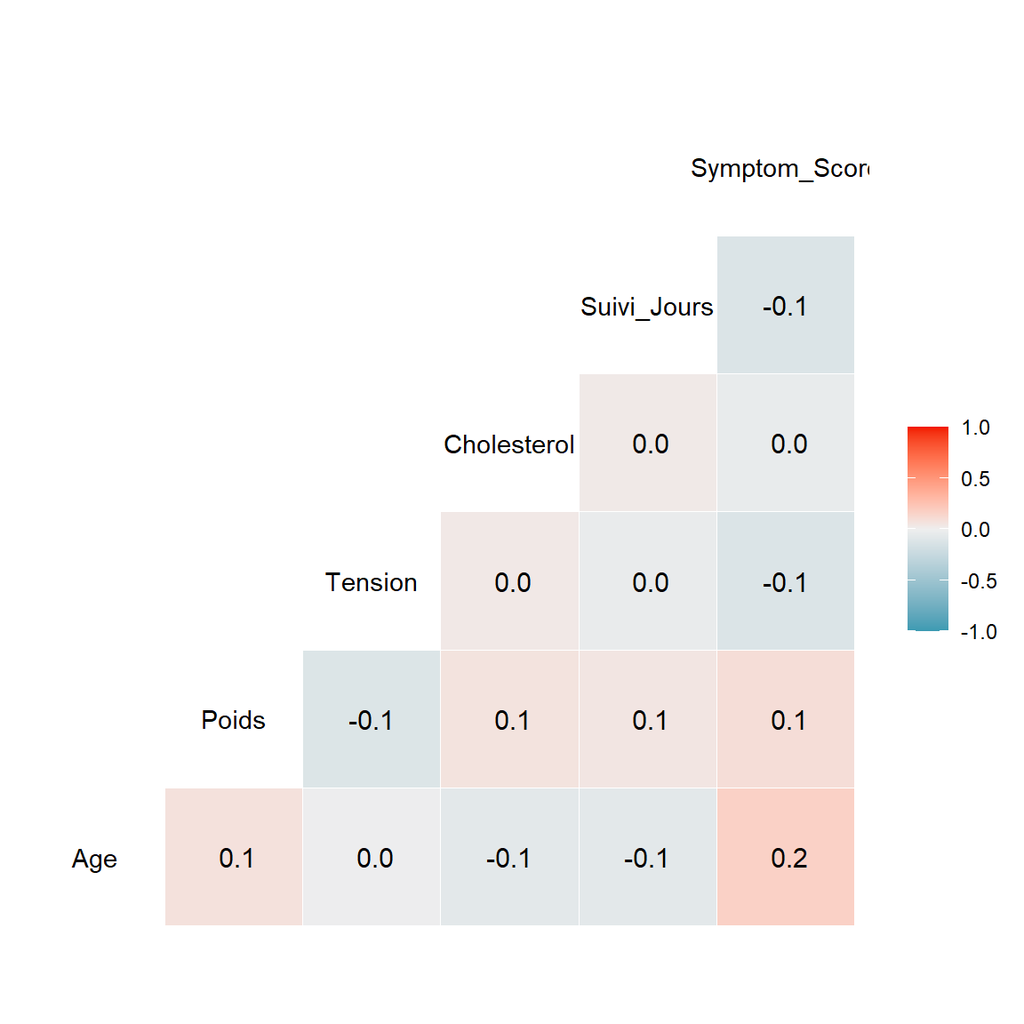

```r
GGally::ggcorr(numeric_vars, label = TRUE)
```

Interprétation :  
- Les coefficients de corrélation proches de **+1** indiquent une relation **croissante forte**,  
- proches de **-1**, une relation **décroissante forte**,  
- proches de **0**, absence de relation linéaire.